# Notebook

### Web Information Retrieval and Data Mining - Assignment 3

```
Student: van Gils, Anna Maria Hendrica (0842844)
```

#### Answer 1.1, Baseline (4p)

- Dense network, at least 3 layers, shaped like a pyramid
  - Last layer: 10 nodes, sigmoid.
  - Loss: categorical cross-entropy. Metric: accuracy
- No preprocessing, regularization. Get at least 70% accuracy.
- Explain design decisions. Discuss performance.
  - Does it overfit (large/growing gap between loss and val_loss)?

[output not shown]

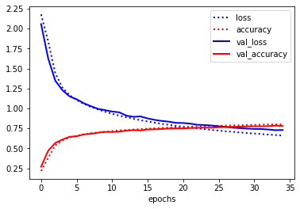

```
Model: "sequential_2"
_________________________________________________________________
Layer (type)                 Output Shape              Param #
=================================================================
reshape_2 (Reshape)          (None, 3072)              0
_________________________________________________________________
dense_13 (Dense)             (None, 1024)              3146752
_________________________________________________________________
dense_14 (Dense)             (None, 512)               524800
_________________________________________________________________
dense_15 (Dense)             (None, 128)               65664
_________________________________________________________________
dense_16 (Dense)             (None, 64)                8256
_________________________________________________________________
dense_17 (Dense)             (None, 32)                2080
_________________________________________________________________
dense_18 (Dense)             (None, 10)                330
=================================================================
Total params: 3,747,882
Trainable params: 3,747,882
Non-trainable params: 0
_________________________________________________________________
None
def build_model_1_1():
  model = models.Sequential()
  model.add(layers.Reshape((3072,), input_shape=(32,32,3)))
  model.add(layers.Dense(1024, activation='tanh'))
  model.add(layers.Dense(512, activation='relu'))
  model.add(layers.Dense(128, activation='relu'))
  model.add(layers.Dense(64, activation='relu'))
  model.add(layers.Dense(32, activation='relu'))
  model.add(layers.Dense(10, activation='softmax'))
  model.compile(optimizer='adagrad',
                  loss='categorical_crossentropy',
                  metrics=['accuracy'])
  return model
```

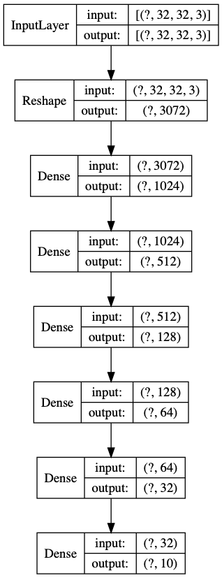

#### Answer 1.2, Preprocess (2p)

- Convert images to greyscale, other preprocessing optional.
  - Input shape should be (32,32,1)
- Explain design decisions. Is it better? Why (not)?
  - Color information is likely not so useful for classification. Greyscale makes the network smaller, less parameters to learn, less likely to overfit.

[output not shown]

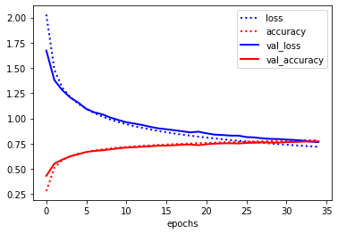

```
Model: "sequential_11"
_________________________________________________________________
Layer (type)                 Output Shape              Param #
=================================================================
reshape_11 (Reshape)         (None, 1024)              0
_________________________________________________________________
dense_67 (Dense)             (None, 1024)              1049600
_________________________________________________________________
dense_68 (Dense)             (None, 512)               524800
_________________________________________________________________
dense_69 (Dense)             (None, 128)               65664
_________________________________________________________________
dense_70 (Dense)             (None, 64)                8256
_________________________________________________________________
dense_71 (Dense)             (None, 32)                2080
_________________________________________________________________
dense_72 (Dense)             (None, 10)                330
=================================================================
Total params: 1,650,730
Trainable params: 1,650,730
Non-trainable params: 0
_________________________________________________________________
None
def build_model_1_2():
  model = models.Sequential()
  model.add(layers.Reshape((1024,), input_shape=(32,32,1)))
  model.add(layers.Dense(1024, activation='tanh'))
  model.add(layers.Dense(512, activation='relu'))
  model.add(layers.Dense(128, activation='relu'))
  model.add(layers.Dense(64, activation='relu'))
  model.add(layers.Dense(32, activation='relu'))
  model.add(layers.Dense(10, activation='softmax'))
  model.compile(optimizer='adagrad',
                  loss='categorical_crossentropy',
                  metrics=['accuracy'])
  return model
```

#### Answer 1.3, Tune (4p)

- Regularize the model. What works best?
  - Should consider batch normalization, dropout, l1/l2 regularization (or Nesterov)
- Tune other hyperparameters (e.g. learning rate, batch size,...) as you see fit.
  - At least consider tuning learning rate, ideally also momentum, decay, other optimizers
- Explain your findings and final design decisions. Discuss the results.
  - Should be better, at least it shouldn't overfit

[output not shown]

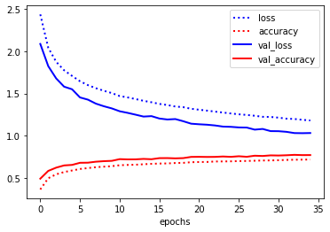

```
def build_model_1_3():
  model = models.Sequential()
  model.add(layers.Reshape((1024,), input_shape=(32,32,1)))
  model.add(layers.Dense(1024, activation='tanh'))
  model.add(layers.Dense(512, kernel_regularizer=regularizers.l2(0.001), activation='relu'))
  model.add(layers.BatchNormalization())
  model.add(layers.Dense(128, activation='relu'))
  model.add(layers.Dropout(0.5))
  model.add(layers.Dense(64, activation='relu'))
  model.add(layers.Dense(32, activation='relu'))
  model.add(layers.Dense(10, activation='softmax'))
  model.compile(optimizer='adagrad',
                  loss='categorical_crossentropy',
                  metrics=['accuracy'])
  return model
```

#### Answer 2.1, ConvNet (7p)

- Build a sequential ConvNet, get at least 90% accuracy.
  - Conv2D layers, input shape (32,32,1)
  - Consider using blocks of Conv2D layers with maxpooling in between
  - Use zero-padding in Conv2D layers because the images are small
  - At least one dense hidden layer and dense output layer (sigmoid)
  - Consider adding batch normalization, dropout
  - Consider small dropout rates in beginning, larger dropout rates later in network
  - Consider other optimizers and tuning learning rate, momentum,...
- Explain what you did and why (800 chars). Is it working well?
  - Should be quite elaborate and sensible

[output not shown]

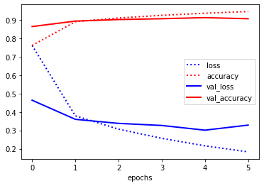

```
Model: "sequential_27"
_________________________________________________________________
Layer (type)                 Output Shape              Param #
=================================================================
conv2d_12 (Conv2D)           (None, 32, 32, 32)        320
_________________________________________________________________
max_pooling2d_8 (MaxPooling2 (None, 16, 16, 32)        0
_________________________________________________________________
conv2d_13 (Conv2D)           (None, 16, 16, 64)        18496
_________________________________________________________________
max_pooling2d_9 (MaxPooling2 (None, 8, 8, 64)          0
_________________________________________________________________
conv2d_14 (Conv2D)           (None, 8, 8, 128)         73856
_________________________________________________________________
flatten_5 (Flatten)          (None, 8192)              0
_________________________________________________________________
dense_147 (Dense)            (None, 256)               2097408
_________________________________________________________________
dense_148 (Dense)            (None, 10)                2570
=================================================================
Total params: 2,192,650
Trainable params: 2,192,650
Non-trainable params: 0
_________________________________________________________________
None
def build_model_2_1():
  model = models.Sequential()
  model.add(layers.Conv2D(32, (3, 3), activation='relu', padding='same', input_shape=(32, 32, 1)))
  model.add(layers.MaxPooling2D((2, 2)))
  model.add(layers.Conv2D(64, (3, 3), activation='relu', padding='same'))
  model.add(layers.MaxPooling2D((2, 2)))
  model.add(layers.Conv2D(128, (3, 3), activation='relu', padding='same'))
  model.add(layers.Flatten())
  model.add(layers.Dense(256, activation='tanh'))
  model.add(layers.Dense(10, activation='softmax'))
  model.compile(optimizer='rmsprop',
                  loss='categorical_crossentropy',
                  metrics=['accuracy'])

  return model
```

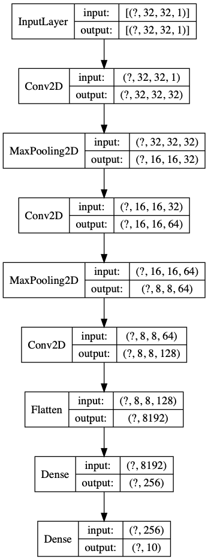

#### Answer 2.2, Data Augmentation (3p)

- Augment the preprocessed training data.
  - Use small variations (small shifts up-down, left-right) of flips becasue the images are small
  - Large shifts and rotations distort the image too much
- Explain what you did and why. Discuss the performance of the model.

[output not shown]

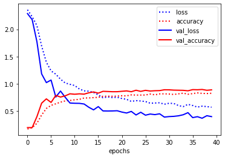

[output not shown]

#### Answer 3.1, Misclassifications (2p)

[output not shown]

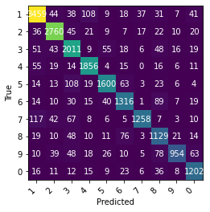

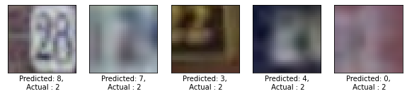

#### Answer 3.2, Activations (4p)

- Retrieve and visualize the activations for one example
- For every filter for different convolutional layers (at different depths in the network).
- Give an explanation. Is your model indeed learning something useful?
  - Should detect edges etc in first layers, higher-order object (e.g. interesting regions) in deeper layers.

[output not shown]

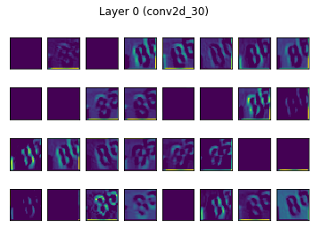

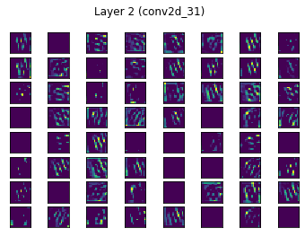

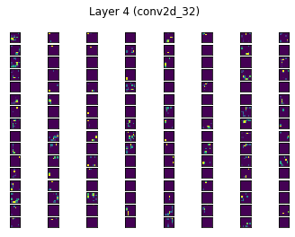

#### Answer 3.3, Class activation map (4p)

- Show a class activation map for your last convolutional layer
- Superimpose the activation map over the image, or plot side by side
  - Should make sense, detect interesting regions to classify the number

```
predicted label:  8
actual label:  8
def plot_3_3():
  model = load_model_from_file(base_dir, "model_2_2")

  image_index = 0

  original_img_tensor = X_test[image_index]
  img_tensor = np.expand_dims(rgb2gray(X_test)[image_index], axis=0)

  predictions = model.predict(img_tensor)
  predicted_label = np.argmax(predictions) + 1
  print("predicted label: ", predicted_label)

  actual_label = np.argwhere(y_test[image_index])[0,0] + 1
  print("actual label: ", actual_label)
  # print("predictions: ", decode_predictions(predictions, top=3)[0])

  # Extracts the outputs and names of the layers:
  layer_outputs = [layer.output for layer in model.layers]
  layer_names = [layer.name for layer in model.layers]
  # Creates a model that will return these outputs, given the model input:
  activation_model = models.Model(inputs=model.input, outputs=layer_outputs)
  # get activations of last convolutional layer
  activations = activation_model.predict(img_tensor)
  layer_activation = activations[-4]

  class_weights = model.layers[-1].get_weights()[0]

  # class of interest is predicted label
  predicted_label_index = predicted_label - 1
  actual_label_index = actual_label - 1

  # show original image
  #######################################
  f, ax = plt.subplots(1,1, figsize=(2,2))
  f.suptitle("Original image")
  ax.imshow(original_img_tensor)
  #######################################

```

[output cut: 38 more lines]

```
    f_cam.suptitle('Class activation map for {}'.format(predicted_label))
    ax_cam.set_xticks([])
    ax_cam.set_yticks([])
  else:
    f_cam, (ax_cam_pred, ax_cam_act) = plt.subplots(1,2, figsize=(4,2.5))
    # plt.rcParams['figure.dpi'] = 120
    ax_cam_pred.imshow(img_predicted)
    ax_cam_act.imshow(img_actual)
    f_cam.suptitle('Class activation maps')
    ax_cam_pred.set_xticks([])
    ax_cam_pred.set_yticks([])
    ax_cam_act.set_xticks([])
    ax_cam_act.set_yticks([])
    ax_cam_pred.set_title("for predicted label {}".format(predicted_label), fontsize=10)
    ax_cam_act.set_title("for actual label {}".format(actual_label), fontsize=10)
```

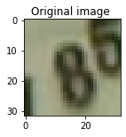

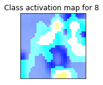

#### Answer 4.1, Fast feature extraction (5p)

- Import the VGG16 model, pretrained on ImageNet
- Freeze convolutional base, adds a dense layer
- Consider unfreezing the last few convolutional layers and evaluate whether that works better
  - Check if they do. It is very likely to help.
- Discuss the observed performance
  - Should get around 80% accuracy

[output not shown]

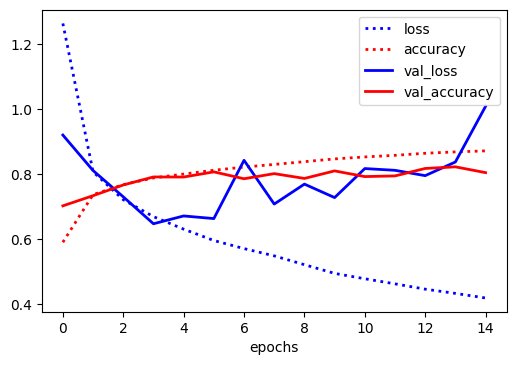

```
Model: "model"
_________________________________________________________________
Layer (type)                 Output Shape              Param #
=================================================================
input_1 (InputLayer)         [(None, 32, 32, 3)]       0
_________________________________________________________________
block1_conv1 (Conv2D)        (None, 32, 32, 64)        1792
_________________________________________________________________
block1_conv2 (Conv2D)        (None, 32, 32, 64)        36928
_________________________________________________________________
block1_pool (MaxPooling2D)   (None, 16, 16, 64)        0
_________________________________________________________________
block2_conv1 (Conv2D)        (None, 16, 16, 128)       73856
_________________________________________________________________
block2_conv2 (Conv2D)        (None, 16, 16, 128)       147584
_________________________________________________________________
block2_pool (MaxPooling2D)   (None, 8, 8, 128)         0
_________________________________________________________________
block3_conv1 (Conv2D)        (None, 8, 8, 256)         295168
_________________________________________________________________
block3_conv2 (Conv2D)        (None, 8, 8, 256)         590080
_________________________________________________________________
block3_conv3 (Conv2D)        (None, 8, 8, 256)         590080
_________________________________________________________________
block3_pool (MaxPooling2D)   (None, 4, 4, 256)         0
_________________________________________________________________
block4_conv1 (Conv2D)        (None, 4, 4, 512)         1180160
_________________________________________________________________
block4_conv2 (Conv2D)        (None, 4, 4, 512)         2359808
_________________________________________________________________
block4_conv3 (Conv2D)        (None, 4, 4, 512)         2359808
_________________________________________________________________
block4_pool (MaxPooling2D)   (None, 2, 2, 512)         0
_________________________________________________________________
block5_conv1 (Conv2D)        (None, 2, 2, 512)         2359808
_________________________________________________________________
block5_conv2 (Conv2D)        (None, 2, 2, 512)         2359808
_________________________________________________________________
block5_conv3 (Conv2D)        (None, 2, 2, 512)         2359808
_________________________________________________________________
```

[output cut: 16 more lines]

```

  model = model_vgg16.output
  model = layers.Flatten()(model)
  model = layers.Dense(10, activation='softmax')(model)

  model_return = models.Model(inputs=model_vgg16.inputs, outputs=model)

  # model.add(model_vgg16)
  # model.add(layers.Flatten())
  # model.add(layers.Dense(256, activation='relu'))
  # model.add(layers.Dense(10, activation='softmax'))

  model_return.compile(optimizer='rmsprop', loss='categorical_crossentropy', metrics=['accuracy'])

  return model_return
```

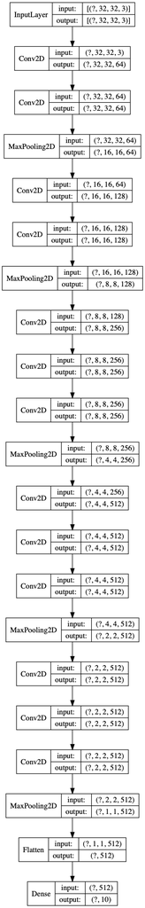

#### Answer 4.2, Embeddings (5p)

- Generate embeddings with the trained convolutional part of model_4_1 (without the dense layer)
- Embed the training and test data and store them to disk
- Build and evaluate a pipeline on the embedded data
  - Check if pipeline makes sense (e.g. use models that can handle many dimensions)
- Describe what you did and what you observed (max 800 chars).
  - Consider different models, preprocessing, tuning, etc.
  - Check performance (see original Submission.html) when in doubt. We did not run all the evaluations because it takes too long, and the output is ill-defined.

[output not shown]

```
Running time: 35.42 seconds
Last modified: May 26, 2020
scikit-learn version: 0.23.1
```